# Presentación de modelos en Análisis de Sentimientos

- Néstor Martínez
- Minería de Textos
- LCD, IIMAS, UNAM
- Mayo, 2022
- **Dataset:** Reseñas en IMDB
- **Modelos evaluados**:
  1. Regresión logística
  2. CNN y RNN
  3. BERT

## 1. Regresión Logística

1. Promedio de vectores de palabras
2. Doc2Vec
3. Sentence-BERT

## Carga de Datos

```python
url = "https://raw.githubusercontent.com/nestorivanmo/datasets/master/imdb/IMDB%20Dataset.csv"
df = pd.read_csv(url)

df.head()
```

|  | review | sentiment |
| --- | --- | --- |
| 0 | One of the other reviewers has mentioned that ... | positive |
| 1 | A wonderful little production. <br /><br />The... | positive |
| 2 | I thought this was a wonderful way to spend ti... | positive |
| 3 | Basically there's a family where a little boy ... | negative |
| 4 | Petter Mattei's "Love in the Time of Money" is... | positive |

```python
print(f"Número de instancias positivas: {num_pos}")
print(f"Número de instancias negativas: {num_neg}")
```

```
Número de instancias positivas: 25000
Número de instancias negativas: 25000
```

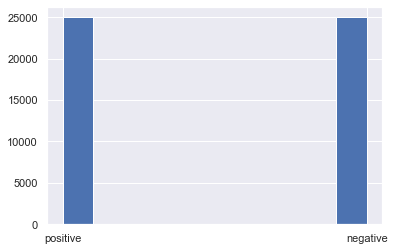

```python
df['sentiment'].hist()
plt.show()
```

## Transformación de datos

```python
temp.head()
```

|  | review | sentiment |
| --- | --- | --- |
| 0 | [one, of, the, other, reviewers, has, mentione... | positive |
| 1 | [a, wonderful, little, production, br, br, the... | positive |
| 2 | [i, thought, this, was, a, wonderful, way, to,... | positive |
| 3 | [basically, there, s, a, family, where, a, lit... | negative |
| 4 | [petter, mattei, s, love, in, the, time, of, m... | positive |

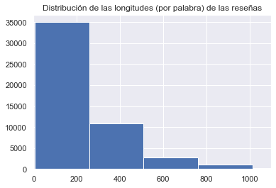

```python
plot_review_length(temp)
```

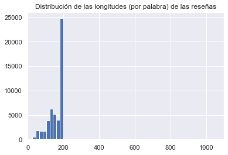

```python
plot_review_length(cleaned_df)
```

## Promedio de Vectores de Palabras

- **word2vec**: https://code.google.com/archive/p/word2vec/

```python
print(f"X_train shape: {len(X_train)}\ty_train shape: {len(y_train)}")
print(f"X_test shape: {len(X_test)}\ty_train shape: {len(y_test)}")
```

```
X_train shape: 33500	y_train shape: 33500
X_test shape: 16500	y_train shape: 16500
```

```python
clf_avg = LogisticRegression(random_state=0).fit(X_train, y_train)
y_pred = clf_avg.predict(X_test)
print(classification_report(y_pred, y_test, labels=[0, 1]))
```

```
              precision    recall  f1-score   support

           0       0.52      0.51      0.51      8369
           1       0.50      0.51      0.51      8131

    accuracy                           0.51     16500
   macro avg       0.51      0.51      0.51     16500
weighted avg       0.51      0.51      0.51     16500
```

## Doc2Vec

```python
clf_doc2vec = LogisticRegression(random_state=0, max_iter=1e5).fit(X_train_doc2vec, y_train_doc2vec)
y_pred_doc2vec = clf_doc2vec.predict(X_test_doc2vec)
print(classification_report(y_test_doc2vec, y_pred_doc2vec, labels=[0, 1]))
```

```
              precision    recall  f1-score   support

           0       0.55      0.46      0.50      8208
           1       0.54      0.64      0.59      8292

    accuracy                           0.55     16500
   macro avg       0.55      0.55      0.54     16500
weighted avg       0.55      0.55      0.54     16500
```

## Sentence-BERT

https://github.com/UKPLab/sentence-transformers

```python
clf_bert = LogisticRegression(random_state=0,solver='lbfgs', max_iter=1e5).fit(X_train_bert, y_train_bert)
y_pred_bert = clf_bert.predict(X_test_bert)
print(classification_report(y_test_bert, y_pred_bert, labels=[0, 1]))
```

```
              precision    recall  f1-score   support

           0       0.57      0.58      0.58      8208
           1       0.58      0.57      0.58      8292

    accuracy                           0.58     16500
   macro avg       0.58      0.58      0.58     16500
weighted avg       0.58      0.58      0.58     16500
```

## Conclusiones

El modelo de machine learning que usé para la clasificación fue una regresión logística por su eficiencia de trabajo con etiquetas binarias. Los resultados que obtuve, y como era de esperarse por la complejidad, fueron en el siguiente orden:

[output not shown]

## 2. CNN y RNN

```python
print(f"Número de palabras en el vocabulario: {len(word2id)}")
```

```
Número de palabras en el vocabulario: 88584
```